# Cuestionario 2 · Visualización multivariada — Clave docente

Bioestadística · Semana 3 · 2026-II

Autor/a

[Nombre del Estudiante](https://www.unimagdalena.edu.co/)

Fecha de publicación

20 de octubre de 2026

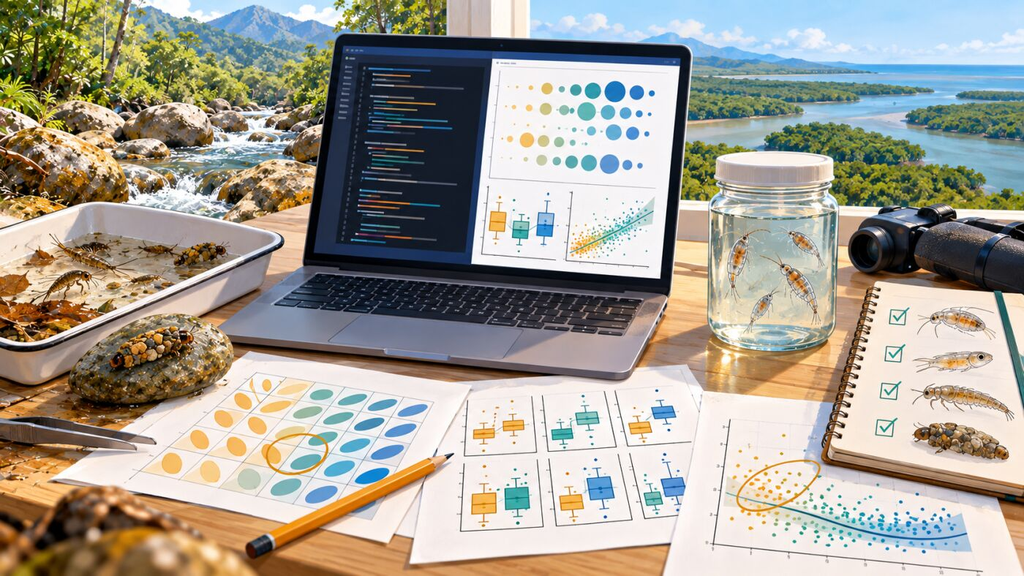

**ImportanteUso de esta clave**

Versión con soluciones de referencia. Otras soluciones son válidas si el código corre desde los datos y la interpretación es correcta. Los valores de esta clave salen de correr el código con `plancton.xlsx` e `Insectos.xlsx`.

## Preparación (se entrega resuelta al estudiante)

```r
# Librerías
library(tidyverse)
library(readxl)
library(kableExtra)
library(corrplot)

# Plancton: base larga depurada
biol <- read_xlsx("plancton.xlsx", sheet = "Riqueza") %>%
  mutate(Groups = str_trim(Groups),
         Station = factor(Station),
         Size = factor(Size),
         Layers = recode_factor(Layers, Depth = "Profunda",
                                Surface = "Superficial"))
taxones <- unique(biol$Groups)

# Plancton: base ancha por muestra
pl_ancho <- biol %>%
  group_by(Station, Size, Layers) %>%
  summarise(across(c(Temperature, Salinity, Density), mean),
            .groups = "drop") %>%
  left_join(biol %>%
              group_by(Station, Size, Layers, Groups) %>%
              summarise(Abundance = sum(Abundance),
                        .groups = "drop") %>%
              pivot_wider(names_from = Groups,
                          values_from = Abundance,
                          values_fill = 0),
            by = c("Station", "Size", "Layers")) %>%
  mutate(Ab = rowSums(across(all_of(taxones))),
         Sal_niv = cut(Salinity, quantile(Salinity, c(0, 1/3, 2/3, 1)),
                       labels = c("Baja", "Media", "Alta"),
                       include.lowest = TRUE))

# Insectos: base hipotética de 4 cuencas × 5 quebradas
ins <- read_excel("Insectos.xlsx", sheet = "Insectos") %>%
  mutate(cuenca = factor(cuenca))
taxa_ins <- c("Efem", "Plec", "Tric", "Dipt", "Cole")
```

## Sección A — Figuras de burbujas

### Pregunta 1

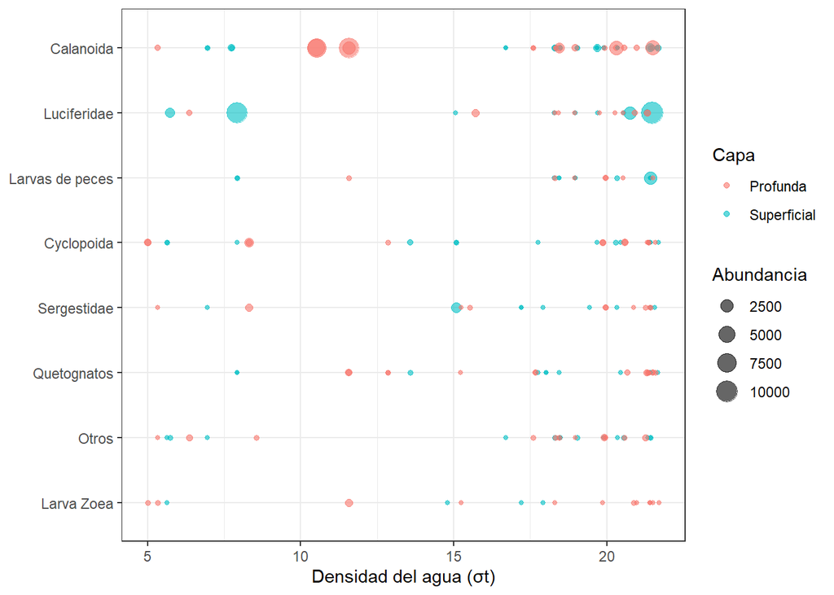

```r
# Taxones ordenados por abundancia total
orden_tax <- biol %>%
  group_by(Groups) %>%
  summarise(Total = sum(Abundance)) %>%
  arrange(desc(Total))
top8 <- orden_tax$Groups[1:8]

# Registros con presencia de los 8 taxones dominantes
burb <- biol %>%
  filter(Groups %in% top8, Abundance > 0) %>%
  mutate(Groups = factor(Groups, levels = rev(top8)))

# Burbujas frente a la densidad del agua
p1 <- ggplot(burb, aes(x = Density, y = Groups,
                       size = Abundance, color = Layers)) +
  geom_point(alpha = 0.6) +
  labs(x = "Densidad del agua (σt)", y = NULL,
       color = "Capa", size = "Abundancia") +
  theme_bw()
p1
```

**Respuesta esperada:** se ordenan los taxones para que los dominantes queden arriba y la figura se lea de mayor a menor; se excluyen los ceros porque una burbuja de tamaño cero no aporta información y satura la figura. La lectura debe nombrar los taxones dominantes (*Calanoida* y *Luciferidae*) y el rango de densidad en que aparecen.

### Pregunta 2

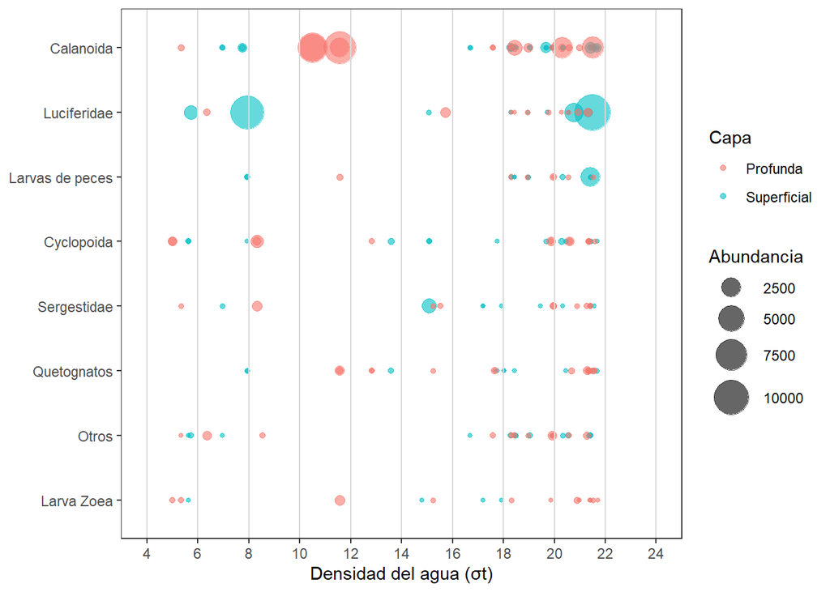

```r
# Escalas y líneas de referencia
p2 <- p1 +
  scale_size(range = c(1, 10), name = "Abundancia") +
  scale_x_continuous(limits = c(4, 24), breaks = seq(4, 24, by = 2)) +
  geom_vline(xintercept = seq(4, 24, by = 2), color = "grey85") +
  theme(panel.grid = element_blank())
p2
```

**Respuesta esperada:** el rango de tamaños evita burbujas diminutas o que se tapen; las líneas verticales permiten leer en qué valor de densidad cae cada burbuja sin la cuadrícula completa. Los límites deben cubrir el rango observado (5 a 21.7).

### Pregunta 3

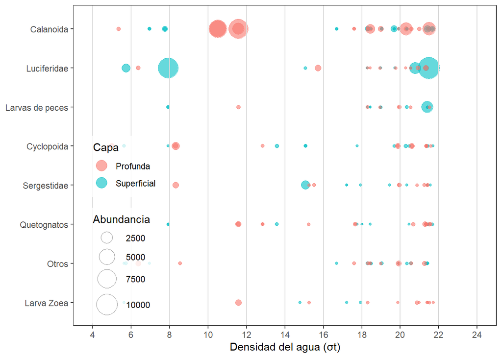

```r
# Leyenda dentro del panel y círculos vacíos en la leyenda de tamaño
p3 <- p2 +
  guides(size  = guide_legend(override.aes = list(shape = 1, color = "grey30")),
         color = guide_legend(override.aes = list(size = 5))) +
  theme(legend.position = c(0.12, 0.3),   # En ggplot2 >= 3.5: legend.position.inside
        legend.background = element_rect(fill = alpha("white", 0.8)))
p3
```

**Respuesta esperada:** la leyenda se ubica donde hay menos burbujas (zona de densidad baja) para no tapar datos; los círculos vacíos muestran el tamaño sin confundirse con un color de capa.

### Pregunta 4

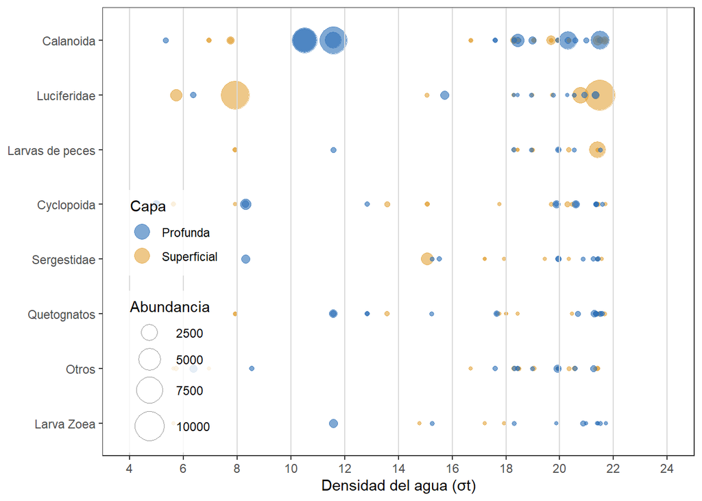

```r
# Paleta y transparencia
p4 <-
  p3 +
  scale_color_manual(values = c(Profunda = "#2C6FB7", Superficial = "#E3A33B"))
p4
```

**Respuesta esperada:** colores contrastantes y distinguibles por personas con daltonismo (azul y ocre, o `viridis`); la transparencia (`alpha`) deja ver burbujas superpuestas.

### Pregunta 5

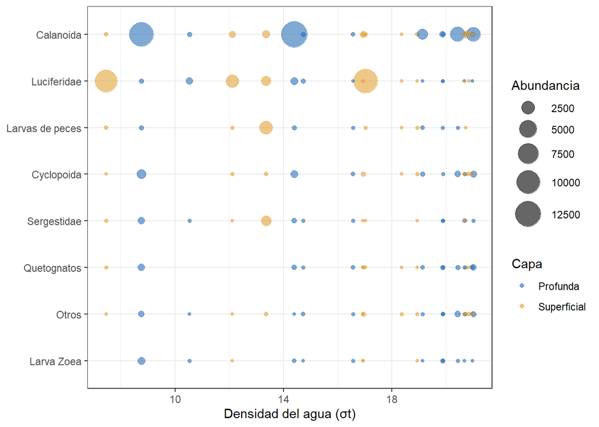

```r
# Burbujas con una burbuja por muestra (base ancha)
burb_m <- pl_ancho %>%
  pivot_longer(all_of(top8),
               names_to = "Groups",
               values_to = "Abundance") %>%
  filter(Abundance > 0) %>%
  mutate(Groups = factor(Groups, levels = rev(top8)))

ggplot(burb_m, aes(x = Density,
                   y = Groups,
                   size = Abundance,
                   color = Layers)) +
  geom_point(alpha = 0.6) +
  scale_size(range = c(1, 10)) +
  scale_color_manual(values = c(Profunda = "#2C6FB7",
                                Superficial = "#E3A33B")) +
  labs(x = "Densidad del agua (σt)",
       y = NULL, color = "Capa",
       size = "Abundancia") +
  theme_bw()
```

```r
# Número de burbujas en cada versión
c(registros = nrow(burb), muestras = nrow(burb_m))
```

```
registros  muestras
      193       149
```

**Respuesta esperada:** la versión con la base ancha tiene 149 burbujas (una por muestra y taxón presente) frente a 193 registros de la hoja larga. Para describir la comunidad por unidad muestral se prefiere la base ancha; la larga repite muestras.

## Sección B — Mapa de exploración

### Pregunta 6

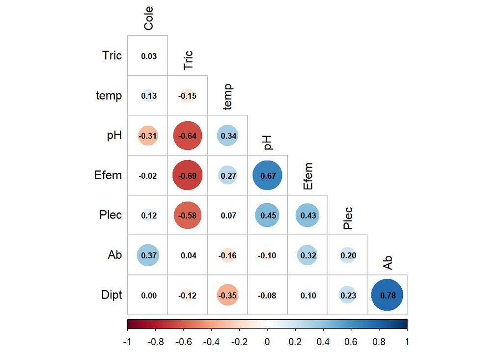

```r
# Matrices de correlación de Pearson y de Spearman con las 8 variables
vars_ins <- c("pH", "temp", taxa_ins, "Ab")
M_p <- cor(ins[, vars_ins], method = "pearson")
M_s <- cor(ins[, vars_ins], method = "spearman")

# Correlograma de círculos con coeficientes, ordenado por agrupamiento (AOE)
corrplot(M_s, method = "circle",
         type = "lower", order = "AOE",
         diag = FALSE,
         addCoef.col = "black",
         number.cex = 0.7,
         tl.col = "black")
```

```r
# Par con mayor |r| de Spearman y su valor de Pearson
M_s0 <- M_s; diag(M_s0) <- 0
ij6 <- which(abs(M_s0) == max(abs(M_s0)),
             arr.ind = TRUE)[1, ]
par6 <- c(rownames(M_s)[ij6[1]],
          colnames(M_s)[ij6[2]])
c(spearman = round(M_s[ij6[1], ij6[2]], 2),
  pearson = round(M_p[ij6[1], ij6[2]], 2))
```

```
spearman  pearson
    0.78     0.77
```

**Respuesta esperada:** el par con mayor |r| de Spearman es Ab–Dipt (ρ = 0.78; r de Pearson = 0.77). Spearman usa rangos, así que es menos sensible a valores extremos y capta relaciones monótonas no lineales; si los dos coeficientes son parecidos, la relación es aproximadamente lineal. El orden AOE agrupa las variables que covarían.

### Pregunta 7

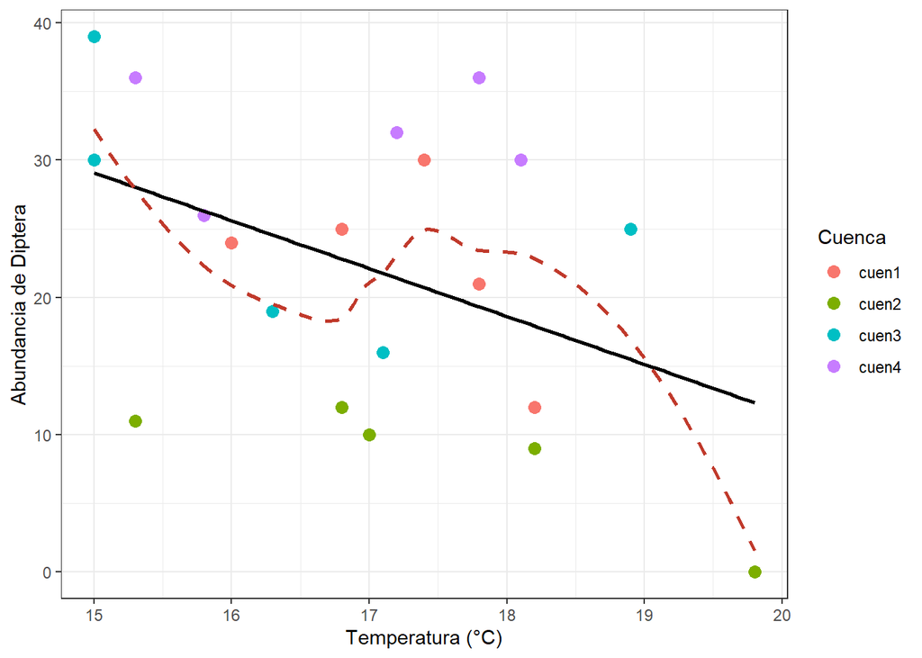

```r
# Dispersión de Diptera frente a la temperatura, con ajuste lineal y loess
ggplot(ins, aes(x = temp, y = Dipt)) +
  geom_point(aes(color = cuenca), size = 3) +
  geom_smooth(method = "lm",
              formula = y ~ x,
              se = FALSE, color = "black") +
  geom_smooth(method = "loess",
              formula = y ~ x, se = FALSE,
              color = "#C0392B",
              linetype = "dashed") +
  labs(x = "Temperatura (°C)",
       y = "Abundancia de Diptera",
       color = "Cuenca") +
  theme_bw()
```

```r
# r global y dentro de cada cuenca
r_p7 <- bind_rows(
  ins %>%
    group_by(cuenca) %>%
    summarise(n = n(), r = cor(temp, Dipt)) %>%
    mutate(cuenca = as.character(cuenca)),
  tibble(cuenca = "Todas", n = nrow(ins),
         r = cor(ins$temp, ins$Dipt))) %>%
  mutate(r = round(r, 2))
r_p7
```

```
# A tibble: 5 × 3
  cuenca     n     r
  <chr>  <int> <dbl>
1 cuen1      5 -0.55
2 cuen2      5 -0.86
3 cuen3      5 -0.54
4 cuen4      5  0.07
5 Todas     20 -0.44
```

**Respuesta esperada:** con todas las quebradas, r = -0.44; dentro de las cuencas va de -0.86 a 0.07, con solo 5 quebradas por cuenca. Se espera que el estudiante compare signo y magnitud dentro de cada cuenca con el global y concluya si la relación se mantiene o si el r global mezcla patrones distintos entre cuencas, reconociendo que con n = 5 los r por cuenca son muy inestables.

### Pregunta 8

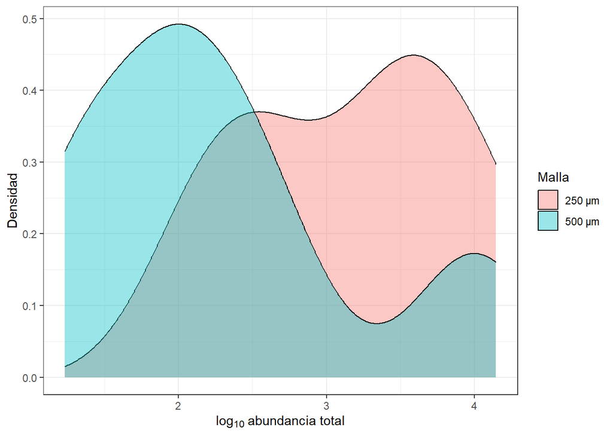

```r
# Densidades por malla
ggplot(pl_ancho, aes(x = log10(Ab), fill = Size)) +
  geom_density(alpha = 0.4) +
  labs(x = expression(log[10]~"abundancia total"),
       y = "Densidad", fill = "Malla") +
  theme_bw()
```

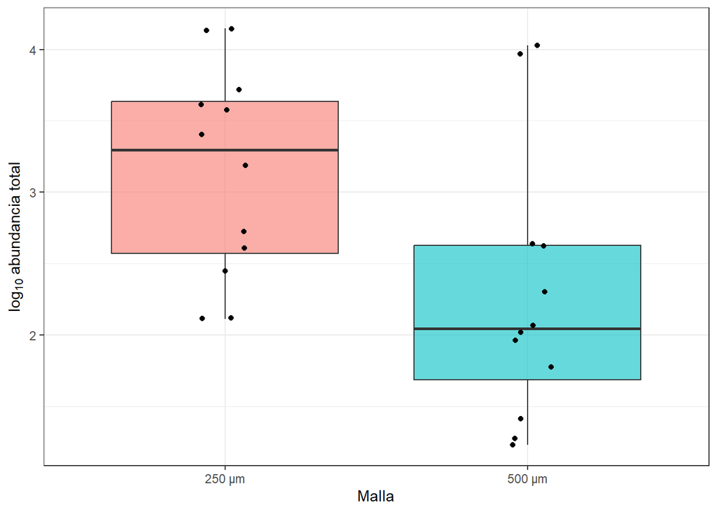

```r
# Cajas con los datos encima
ggplot(pl_ancho, aes(x = Size,
                     y = log10(Ab),
                     fill = Size)) +
  geom_boxplot(alpha = 0.6,
               outlier.shape = NA) +
  geom_jitter(width = 0.08) +
  labs(x = "Malla", y = expression(log[10]~"abundancia total")) +
  theme_bw() + theme(legend.position = "none")
```

```r
# Resumen por malla
res_malla <- pl_ancho %>%
  group_by(Size) %>%
  summarise(n = n(),
            mediana = median(log10(Ab)),
            min = min(log10(Ab)),
            max = max(log10(Ab)))
res_malla
```

```
# A tibble: 2 × 5
  Size       n mediana   min   max
  <fct>  <int>   <dbl> <dbl> <dbl>
1 250 μm    12    3.29  2.11  4.15
2 500 μm    12    2.04  1.23  4.03
```

**Respuesta esperada:** la malla de 250 μm captura más que la de 500 μm (medianas de 3.29 y 2.04 en log10). Se describen posición, dispersión y n (12 por malla), y se muestran los puntos porque n es pequeño.

### Pregunta 9

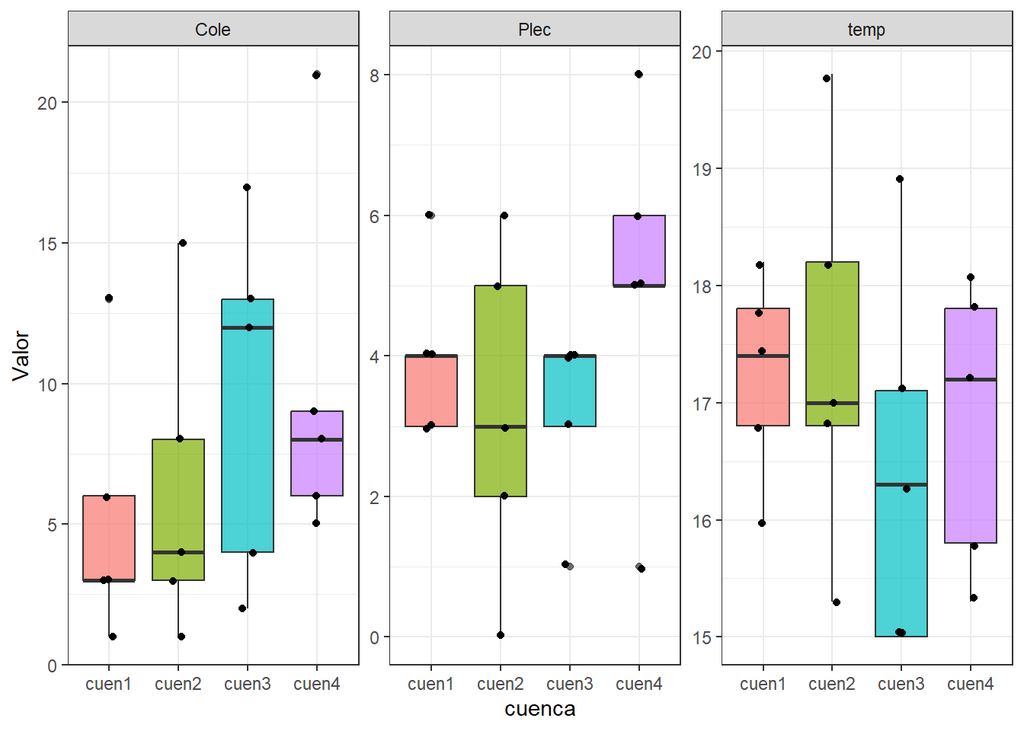

```r
# Un panel por variable, por cuenca
ins %>%
  select(cuenca, temp, Plec, Cole) %>%
  pivot_longer(-cuenca, names_to = "Variable",
               values_to = "Valor") %>%
  ggplot(aes(x = cuenca,
             y = Valor,
             fill = cuenca)) +
  geom_boxplot(alpha = 0.7) +
  geom_jitter(width = 0.08, size = 1.5) +
  facet_wrap(~ Variable, scales = "free_y") +
  theme_bw() + theme(legend.position = "none")
```

```r
# Medianas por cuenca
med9 <- ins %>% group_by(cuenca) %>%
  summarise(across(c(temp, Plec, Cole), median))
med9
```

```
# A tibble: 4 × 4
  cuenca  temp  Plec  Cole
  <fct>  <dbl> <dbl> <dbl>
1 cuen1   17.4     4     3
2 cuen2   17       3     4
3 cuen3   16.3     4    12
4 cuen4   17.2     5     8
```

**Respuesta esperada:** ninguna de las tres variables separa claramente las cuencas. Coleoptera tiene la mediana más alta en la cuenca 3, pero sus rangos se solapan por completo entre cuencas (medianas de temperatura de 16.3 a 17.4 °C; de Plecoptera, de 3 a 5; de Coleoptera, de 3 a 12). Se espera una lectura que distinga solapamiento de separación y que mencione el n = 5 por cuenca.

### Pregunta 10

```r
# Media y e.e. de la abundancia por nivel de salinidad y capa
res_sc <- pl_ancho %>%
  group_by(Sal_niv, Layers) %>%
  summarise(n = n(),
            media = mean(Ab) / 1000,
            ee = sd(Ab) / sqrt(n()) / 1000,
            .groups = "drop")
res_sc
```

```
# A tibble: 6 × 5
  Sal_niv Layers          n media    ee
  <fct>   <fct>       <int> <dbl> <dbl>
1 Baja    Profunda        5 5.66  3.31
2 Baja    Superficial     3 5.70  1.99
3 Media   Profunda        3 0.689 0.434
4 Media   Superficial     5 2.26  2.11
5 Alta    Profunda        4 2.02  1.11
6 Alta    Superficial     4 0.223 0.118
```

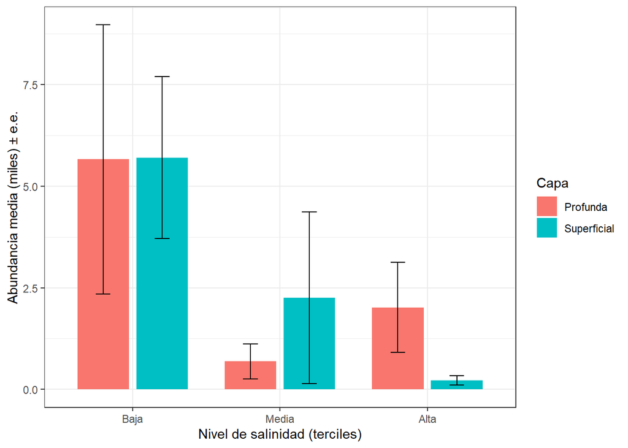

```r
# Barras ± e.e.
ggplot(res_sc, aes(x = Sal_niv,
                   y = media,
                   fill = Layers)) +
  geom_col(position = position_dodge(0.8),
           width = 0.7) +
  geom_errorbar(aes(ymin = pmax(media - ee, 0),
                    ymax = media + ee),
                position = position_dodge(0.8),
                width = 0.2) +
  labs(x = "Nivel de salinidad (terciles)",
       y = "Abundancia media (miles) ± e.e.",
       fill = "Capa") +
  theme_bw()
```

**Respuesta esperada:** las celdas tienen entre 3 y 5 muestras, así que las barras son poco precisas y la lectura es tentativa. Se declara que las barras son e.e. Se espera un párrafo de reporte con la estructura del recuadro «Cómo reportar el resultado» del Taller 6, que mencione el n por celda y la limitación de un factor derivado de una variable continua.